# Hillstrom Randomized Email Experiment

An R case study in experiment analysis using public data

Carlos Gabriel Orellana Heredia

August 01, 2026

# Executive summary

This report analyzes a public randomized email experiment. The primary question is whether sending the Men’s email, compared with sending no email, increased conversion and spend in the following two weeks. Random assignment supports a direct intention-to-treat comparison without propensity-score adjustment.

# Experimental design

Customers were randomly assigned to one of three arms: no email, Men’s email, or Women’s email. The primary analysis prespecifies Men’s email versus no email. Conversion is the primary outcome; spend per customer is the business outcome, and site visit is an engagement outcome.

Observed outcomes across the three randomized arms

| Randomized assignment | Individuals | Visit probability | Conversion probability | Spend per customer (USD) |
| --- | --- | --- | --- | --- |
| No email | 21306 | 10.6% | 0.57% | $0.65 |
| Men’s email | 21307 | 18.3% | 1.25% | $1.42 |
| Women’s email | 21387 | 15.1% | 0.88% | $1.08 |

# Randomization check

The primary groups should be balanced on pre-assignment customer characteristics. Balance is presented as standardized mean differences; values below 0.10 are generally small in magnitude.

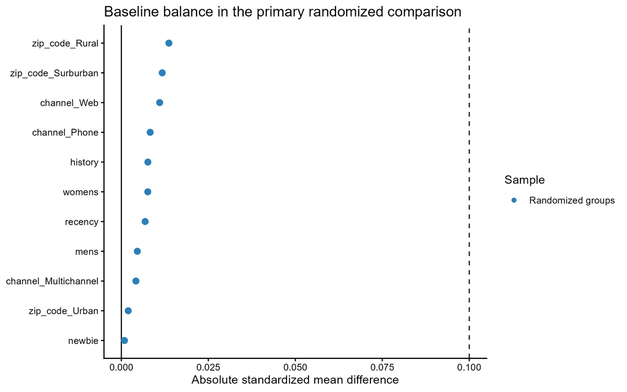

Baseline balance: Men’s email versus no email

| Baseline characteristic | Standardized mean difference | Absolute SMD | Balanced (<0.10) |
| --- | --- | --- | --- |
| recency | 0.007 | 0.007 | TRUE |
| history | 0.008 | 0.008 | TRUE |
| mens | -0.005 | 0.005 | TRUE |
| womens | 0.008 | 0.008 | TRUE |
| zip_code_Rural | 0.014 | 0.014 | TRUE |
| zip_code_Surburban | -0.012 | 0.012 | TRUE |
| zip_code_Urban | 0.002 | 0.002 | TRUE |
| newbie | -0.001 | 0.001 | TRUE |
| channel_Multichannel | -0.004 | 0.004 | TRUE |
| channel_Phone | -0.008 | 0.008 | TRUE |
| channel_Web | 0.011 | 0.011 | TRUE |

# Primary experiment estimates

Effects are absolute differences between the randomized Men’s email and no-email groups. For binary outcomes, they are percentage-point differences; for spend, they are dollars per customer.

Primary randomized comparison: Men’s email minus no email

| Outcome | Control n | Email n | Control outcome | Email outcome | Incremental effect | 95% CI | P value |
| --- | --- | --- | --- | --- | --- | --- | --- |
| Conversion probability | 21306 | 21307 | 0.57% | 1.25% | 0.68% | 0.50% to 0.86% | <0.001 |
| Visit probability | 21306 | 21307 | 10.62% | 18.28% | 7.66% | 7.00% to 8.32% | <0.001 |
| Spend per customer (USD) | 21306 | 21307 | $0.65 | $1.42 | $0.77 | $0.49 to $1.05 | <0.001 |

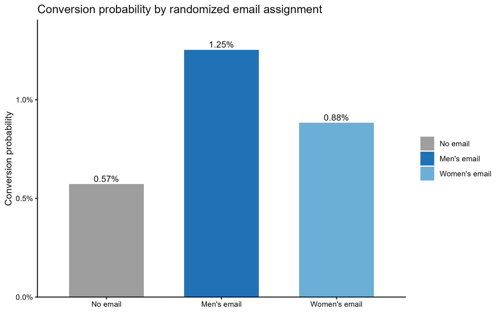

# Experiment planning: power and MDE

This section uses the no-email conversion rate as a planning baseline. It reports the sample size needed to detect selected absolute conversion lifts with 80% power and the minimum detectable effect (MDE) for the approximately equal-sized primary comparison.

Sample size required for 80% power, two-sided alpha = 0.05

| Control conversion rate | Absolute conversion lift | Required individuals per arm | Required total individuals |
| --- | --- | --- | --- |
| 0.57% | 0.25% | 17399 | 34798 |
| 0.57% | 0.50% | 5122 | 10244 |
| 0.57% | 0.75% | 2619 | 5238 |
| 0.57% | 1.00% | 1665 | 3330 |

Minimum detectable effect for the primary comparison

| Control conversion rate | Individuals per arm | Target power | Minimum detectable effect |
| --- | --- | --- | --- |
| 0.57% | 21306 | 80% | 0.22% |

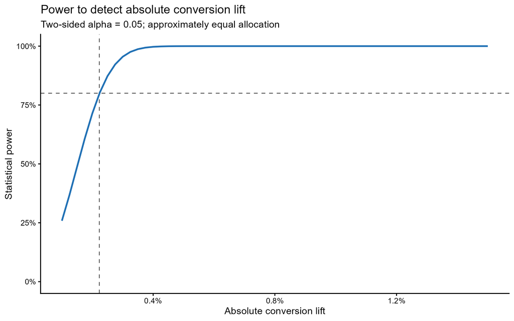

# Exploratory segmentation

The following subgroup estimates are exploratory. They describe whether conversion lift appears to vary by pre-campaign spending category; they should not be interpreted as a production targeting rule without validation in a new experiment.

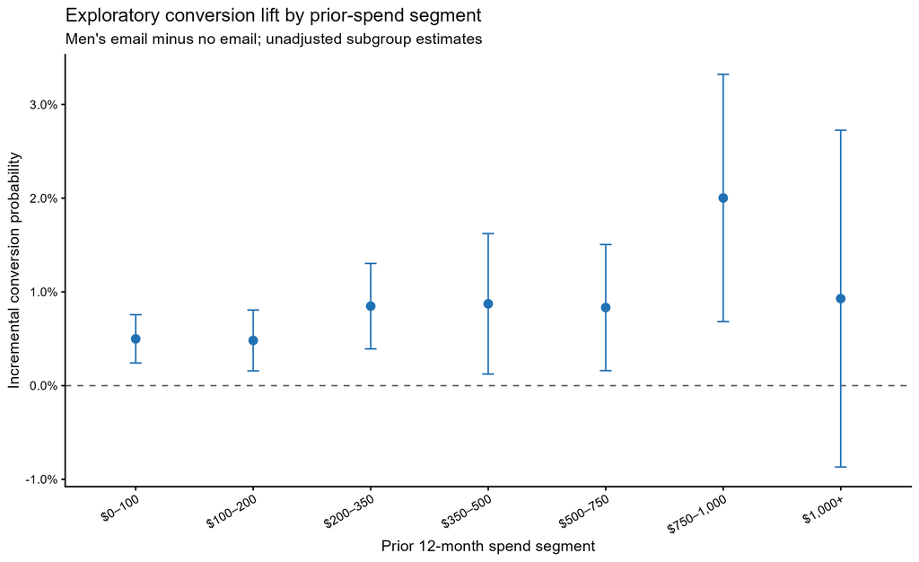

Exploratory conversion lift by prior-spend segment

| Prior-spend segment | Control n | Email n | Control conversion | Email conversion | Incremental conversion | 95% CI |
| --- | --- | --- | --- | --- | --- | --- |
| 1) $0 - $100 | 7612 | 7724 | 0.42% | 0.92% | 0.50% | 0.24% to 0.76% |
| 2) $100 - $200 | 4836 | 4691 | 0.41% | 0.90% | 0.48% | 0.16% to 0.81% |
| 3) $200 - $350 | 4044 | 4090 | 0.69% | 1.54% | 0.85% | 0.39% to 1.30% |
| 4) $350 - $500 | 2124 | 2097 | 1.13% | 2.00% | 0.87% | 0.12% to 1.62% |
| 5) $500 - $750 | 1652 | 1597 | 0.54% | 1.38% | 0.83% | 0.16% to 1.51% |
| 6) $750 - $1,000 | 622 | 644 | 0.48% | 2.48% | 2.00% | 0.68% to 3.32% |
| 7) $1,000 + | 416 | 464 | 1.44% | 2.37% | 0.93% | -0.87% to 2.73% |

# Limitations

This public dataset reflects a historical email experiment rather than a contemporary Twitch product surface. The analysis demonstrates transferable experimentation principles: randomized assignment, intention-to-treat estimation, uncertainty intervals, business metrics, and cautious interpretation of heterogeneity.

# Reproducibility

The raw source data are downloaded locally and excluded from version control. Recreate the workflow from the repository root with:

```r
source("run_all.R")

rmarkdown::render(
  "analysis_report.Rmd",
  output_file = "index.html",
  output_dir = "docs"
)
```